# ADS_Project1_YueZhang

YueZhang yz3383

2/3/2019

# Part I: Text Pre-Processing

### 1) Load Packages

To begin the analysis of all Happy Moments, it’s important to do some pre-processing to the data we have. This part mainly focus on loading the data and merge the variables I want to analyze into a new dataset called ds2.

```r
library(tm)
library(tidytext)
library(tidyverse)
library(DT)
library(wordcloud)
library(RColorBrewer)
library(ngram)  # wordcount()
library(gplots) # heatmap.2()
library(ggraph) # a network of bigrams

ds_main <- read.csv("../data/cleaned_hm.csv")
ds_de <- read.csv("../data/demographic.csv",na.strings=c(""))
ds1 <- ds_main %>%
  select(wid,cleaned_hm,predicted_category)
```

### 2) Preliminary cleaning of text

First of all, we clean the text by converting all the letters to the lower case, and removing punctuation, numbers, empty words and extra white space.

```r
corpus <- VCorpus(VectorSource(ds1$cleaned_hm))%>%
  tm_map(content_transformer(tolower))%>%
  tm_map(removePunctuation)%>%
  tm_map(removeNumbers)%>%
  tm_map(removeWords, character(0))%>%
  tm_map(stripWhitespace)
```

### 3) Stemming words and converting tm object to tidy object

Stemming reduces a word to its word *stem*. We stem the words here and then convert the “tm” object to a “tidy” object for much faster processing.

```r
stemmed <- tm_map(corpus, stemDocument) %>%
  tidy() %>%
  select(text)
```

### 4) Creating tidy format of the dictionary to be used for completing stems

We also need a dictionary to look up the words corresponding to the stems.

```r
dict <- tidy(corpus) %>%
  select(text) %>%
  unnest_tokens(dictionary, text)
```

### 5) Removing stopwords that don’t hold any significant information for our data set

We remove stopwords provided by the “tidytext” package and also add custom stopwords in context of our data.

```r
data("stop_words")

word <- c("happy","ago","yesterday","lot","today","months","month",
                 "happier","happiest","last","week","past")

stop_words <- stop_words %>%
  bind_rows(mutate(tibble(word), lexicon = "updated"))
```

### 6) Combining stems and dictionary into the same tibble

Here we combine the stems and the dictionary into the same “tidy” object.

```r
completed <- stemmed %>%
  mutate(id = row_number()) %>%
  unnest_tokens(stems, text) %>%
  bind_cols(dict) %>%
  anti_join(stop_words, by = c("dictionary" = "word"))
```

### 7) Stem completion

Lastly, we complete the stems by picking the corresponding word with the highest frequency.

```r
completed <- completed %>%
  group_by(stems) %>%
  count(dictionary) %>%
  mutate(word = dictionary[which.max(n)]) %>%
  ungroup() %>%
  select(stems, word) %>%
  distinct() %>%
  right_join(completed) %>%
  select(-stems)
```

### 8) Pasting stem completed individual words into their respective happy moments

We want our processed words to resemble the structure of the original happy moments. So we paste the words together to form happy moments.

```r
completed <- completed %>%
  group_by(id) %>%
  summarise(text = str_c(word, collapse = " ")) %>%
  ungroup()
```

```r
ds1 <- ds1 %>%
  mutate(id = row_number()) %>%
  inner_join(completed)
```

### 9) Merge demographic information with ds1 and create a new dataset ds2

```r
ds2 <- ds1 %>%
  inner_join(.,ds_de,by = "wid") %>%
  select(wid,
         cleaned_hm,
         gender,
         marital,
         parenthood,
         age,
         country,
         predicted_category,
         text) %>%
  mutate(count = sapply(ds1$text, wordcount)) %>%
  filter(gender %in% c("m", "f")) %>%
  filter(marital %in% c("single", "married")) %>%
  filter(parenthood %in% c("n", "y"))
```

# Part II: Play with the Words!

### 1) Analyze Single Word

```r
bag_of_words <-  ds2 %>%
  unnest_tokens(word, text)

word_count <- bag_of_words %>%
  count(word, sort = TRUE)

set.seed(1)
dev.new(width = 2000, height = 2000, unit = "px") # adjust the format to fit all words
# jpeg("../figs/WordCloud.jpeg") # used to save the plot
wordcloud(words = word_count$word, freq = word_count$n, min.freq = 1,
          max.words=100,random.order=FALSE,
          colors=brewer.pal(8, "Dark2"))
# dev.off() # used to save the plot
```

[output not shown]

### 2) Analyze Bigrams

Sometimes two words seem to be more reseonable when they are put together than analyze seperately. So it is necessary to find out all the bigrams and see the frequency of bigrams. First step is to get all bigrams from the text in dataset ds2. I noticed that “spent time” and “spend time” are counted as different terms in the top 10 frequanet bigrams, but in fact they have the same meaning. So I substitued “spent time” by “spend time” to avoid repetition.

```r
ds_bigrams <- ds2 %>%
  filter(count != 1) %>%
  unnest_tokens(bigram, text, token = "ngrams", n = 2)

# Exclude repetition in top 10 bigrams
fixed_ds_bigrams <- ds_bigrams
fixed_ds_bigrams$bigram <- gsub("spent time", "spend time", fixed_ds_bigrams$bigram)
```

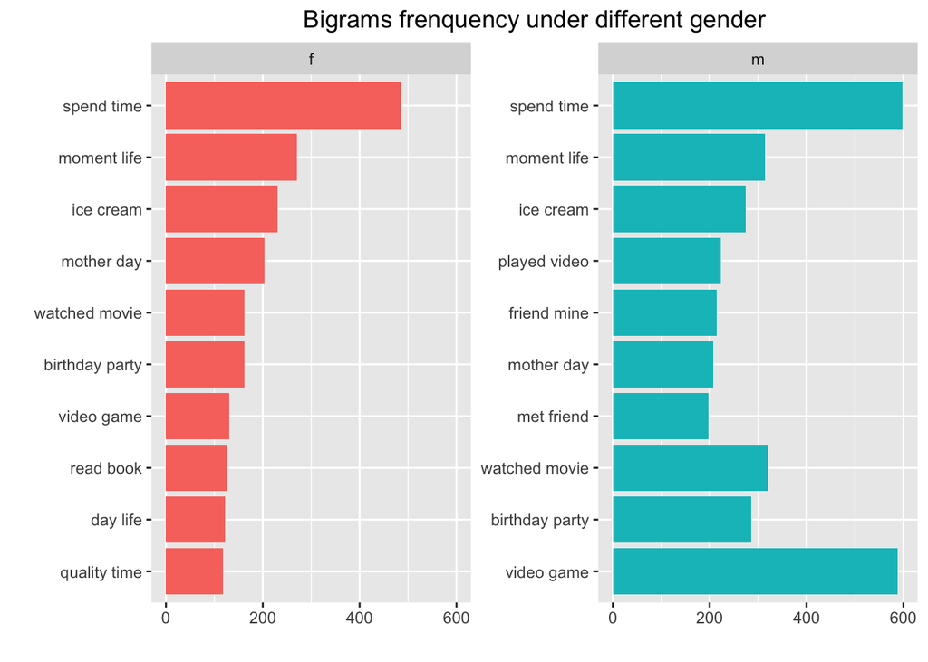

```r
bigrams_gender <- fixed_ds_bigrams %>%
  select(gender,bigram) %>%
  count(gender,bigram) %>%
  group_by(gender) %>%
  arrange(gender,desc(n)) %>%
  filter(row_number() <= 10)

# jpeg("../figs/bigrams_gender.jpeg") # used to save the plot
bigrams_gender %>%
  group_by(gender) %>%
  top_n(10, n) %>%
  arrange(n) %>%
  ungroup() %>%
  mutate(bigram = factor(bigram, unique(bigram))) %>%
  ungroup() %>%
  ggplot(aes(bigram, n, fill = gender)) +
  geom_col(show.legend = FALSE) +
  facet_wrap(~ gender, scales = "free", ncol = 2) +
  coord_flip() +
  labs(x = "",
       y = "") +
  ylim(c(0,600)) +
  ggtitle("Bigrams frenquency under different gender") +
  theme(plot.title = element_text(hjust = 0.5))
```

```r
# dev.off() # used to save the plot
```

I also plot the barcharts of bigrams under different marital status and different parenthood experience as below. From the bigrams regrad to marital we can see that single person tend to spend much more time on vedio games than married ones. From the bigrams regrad to parenthood we can see that people raised with parenthood tend to spend less time on vedio games than people raised with parenthood. But they both feel happy on their birthday parties and mother’s days.

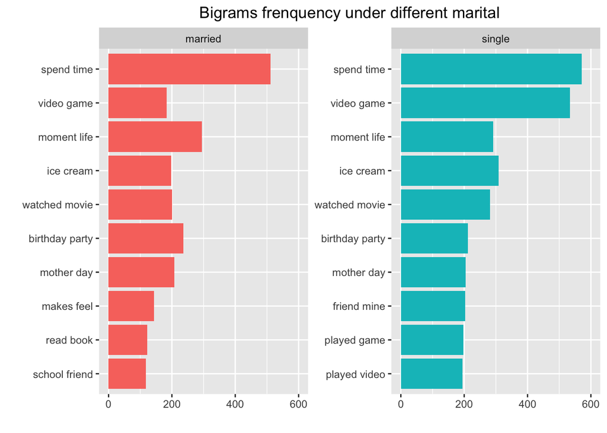

```r
bigrams_marital <- fixed_ds_bigrams %>%
  select(marital,bigram) %>%
  count(marital,bigram) %>%
  group_by(marital) %>%
  arrange(marital,desc(n)) %>%
  filter(row_number() <= 10)

# jpeg("../figs/bigrams_marital.jpeg") # used to save the plot
ggplot(bigrams_marital,aes(x = reorder(bigram,n),y = n, fill = marital)) +
  geom_col(show.legend = FALSE) +
  labs(x = "", y = "") +
  facet_wrap(~marital, ncol = 2, scales = "free") +
  coord_flip() +
  ylim(c(0,600)) +
  ggtitle("Bigrams frenquency under different marital") +
  theme(plot.title = element_text(hjust = 0.5))
```

```r
# dev.off() # used to save the plot
```

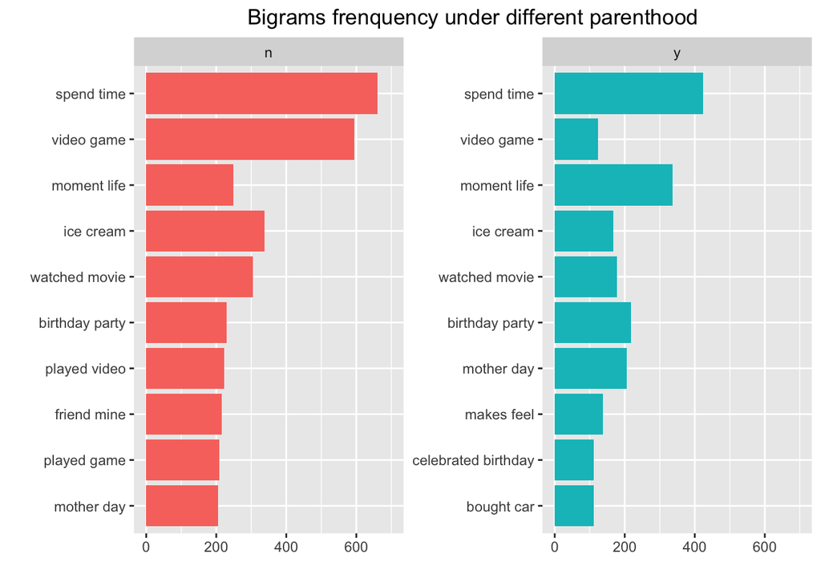

```r
bigrams_parenthood <- fixed_ds_bigrams %>%
  select(parenthood,bigram) %>%
  count(parenthood,bigram) %>%
  group_by(parenthood) %>%
  arrange(parenthood,desc(n)) %>%
  filter(row_number() <= 10)

# jpeg("../figs/bigrams_parenthood.jpeg") # used to save the plot
ggplot(bigrams_parenthood,aes(x = reorder(bigram,n),y = n, fill = parenthood)) +
  geom_col(show.legend = FALSE) +
  labs(x = "", y = "") +
  facet_wrap(~parenthood, ncol = 2, scales = "free") +
  coord_flip() +
  ylim(c(0,700)) +
  ggtitle("Bigrams frenquency under different parenthood") +
  theme(plot.title = element_text(hjust = 0.5))
```

```r
# dev.off() # used to save the plot
```

### 3) Correlation Between Bigrams

We can explore the inner connection between all bigrams using ggraph and visualize the netword of them. As you can see, happy moment words like friends,family are usually connected with talk,visit,dinner, ect. Also, most happy moments are connected with friends, family, vedio games, birthdays, it’s more detailed and more resonable compared to the sigle word’s wordcloud plot.

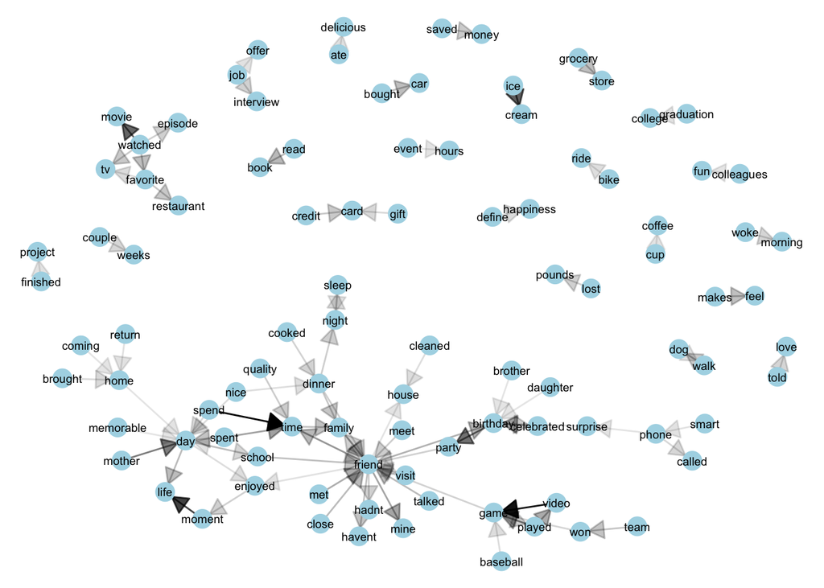

```r
library(igraph) #graph_from_data_frame
library(ggraph)

bigram_counts <- ds_bigrams %>%
  separate(bigram, c("word1", "word2"), sep = " ") %>%
  count(word1, word2, sort = TRUE)

bigram_graph <- bigram_counts %>%
  filter(n > 110) %>%
  graph_from_data_frame()

set.seed(2)

a <- grid::arrow(type = "closed", length = unit(.15, "inches"))

# jpeg("../figs/bigrams_network.jpeg") # used to save the plot
ggraph(bigram_graph, layout = "fr") +
  geom_edge_link(aes(edge_alpha = n), show.legend = FALSE,
                 arrow = a, end_cap = circle(.07, 'inches')) +
  geom_node_point(color = "lightblue", size = 5) +
  geom_node_text(aes(label = name),size = 2.5, vjust = 0.5, hjust = 0.5) +
  theme_void()
```

```r
# dev.off() # used to save the plot
```

# Part III: Play with the Categories

Using the predicted_category variable in ds2, we can assign each word with a clearer category. In total, there are 7 categories: chievement, affection,bouding,enjoy_the_moment,exercise,leisure and natrue. These category labels are easied to understand than hunderds of words. I used barcharts under different gender, marital and parenthood to show theie difference under each category label.

From the first plot, it’s claer to see that the contrast between female and male in categories like achievement and affection. Female have more happy moments regrads to affection while male enjoy achivement more.

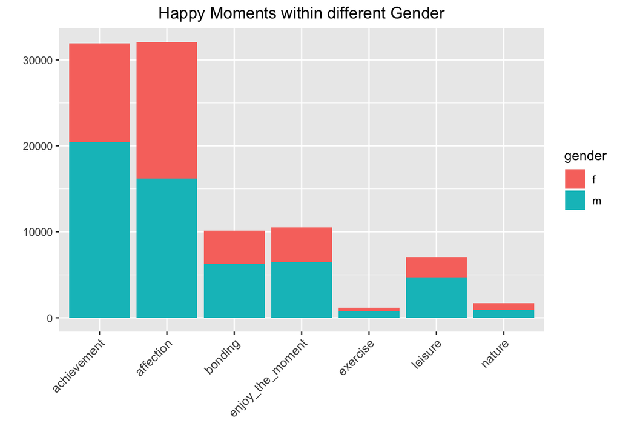

```r
# jpeg("../figs/bar_gender.jpeg") # used to save the plot
ggplot(ds2,aes(x= predicted_category, fill=gender)) +
  geom_bar(stat="count") +
  ggtitle("Happy Moments within different Gender") +
  labs(x = "",y = "") +
  theme(plot.title = element_text(hjust = 0.5),
        axis.text.x = element_text(size  = 10,
                                angle = 45,
                                hjust = 1,
                                vjust = 1))
```

```r
# dev.off() # used to save the plot
```

From the second plot, contrast between married and single also can be seen easily in achievement and affection. Married people seems more sensitive in emotion compared to the single ones, who are more ambitious and enjoy achievement more.

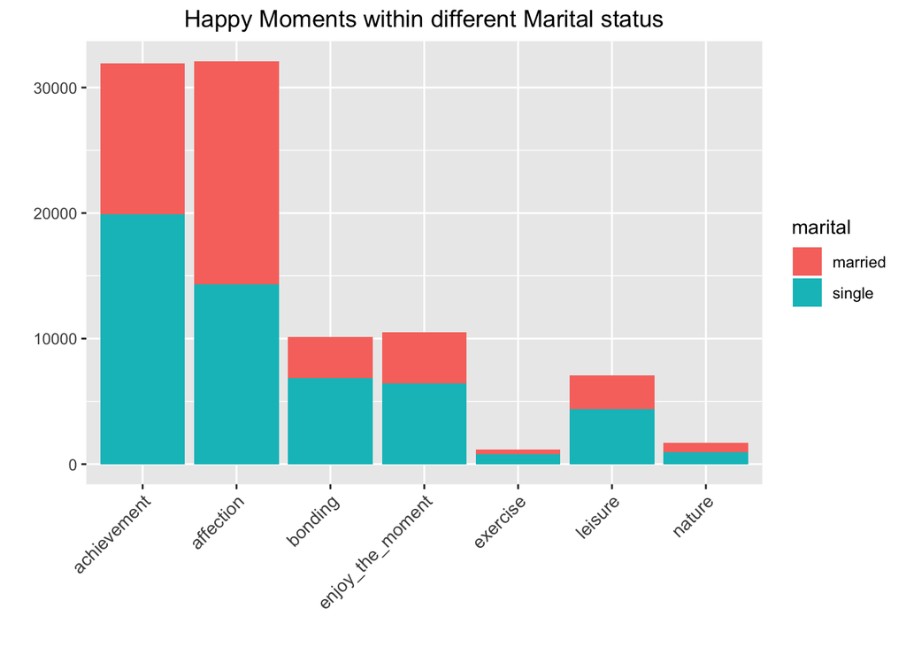

```r
# jpeg("../figs/bar_marital.jpeg") # used to save the plot

ggplot(ds2,aes(x= predicted_category, fill=marital)) +
  geom_bar(stat="count") +
  ggtitle("Happy Moments within different Marital status") +
  labs(x = "",y = "") +
  theme(plot.title = element_text(hjust = 0.5),
        axis.text.x = element_text(size  = 10,
                                angle = 45,
                                hjust = 1,
                                vjust = 1))
```

```r
# dev.off() # used to save the plot
```

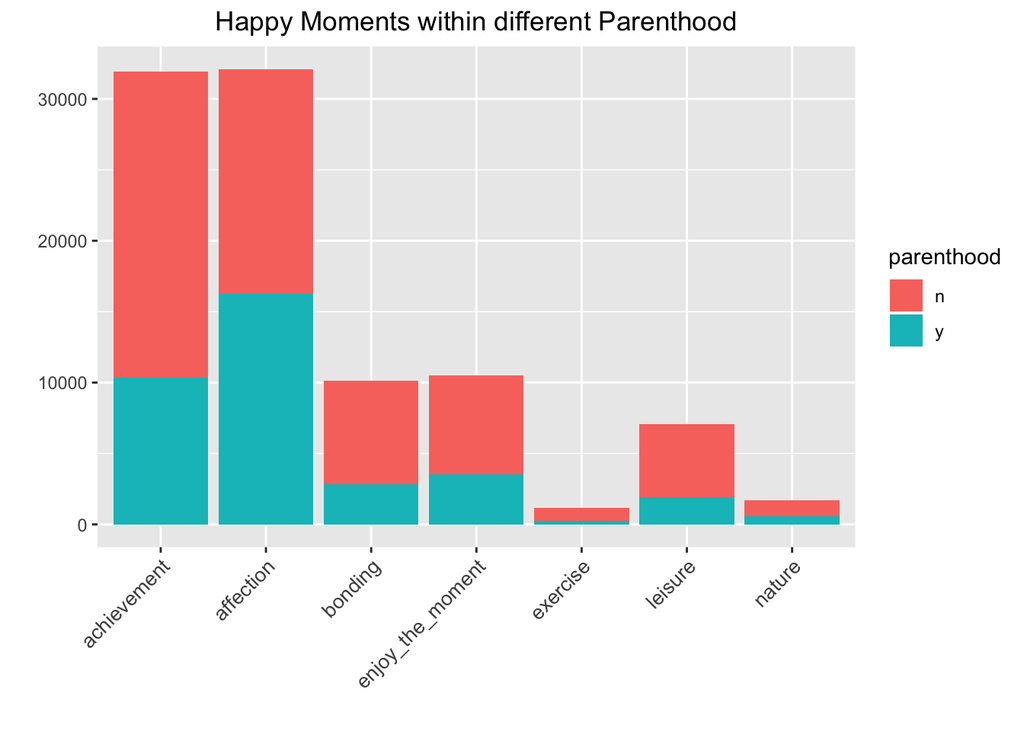

```r
# jpeg("../figs/bar_parenthood.jpeg") # used to save the plot

ggplot(ds2,aes(x= predicted_category, fill=parenthood)) +
  geom_bar(stat="count") +
  ggtitle("Happy Moments within different Parenthood") +
  labs(x = "",y = "") +
  theme(plot.title = element_text(hjust = 0.5),
        axis.text.x = element_text(size  = 10,
                                angle = 45,
                                hjust = 1,
                                vjust = 1))
```

```r
# dev.off() # used to save the plot
```

### Heatmap mixture of all these variables.

Too many plots to understand? Let’s look at heatmap and draw a conclusion. Here I make a new variable called category, which contains all possible combinations of gender,marital and parenthood. Then generate a matrix using the frenquency of words in each category to cluster these combinations and the categorical labels.

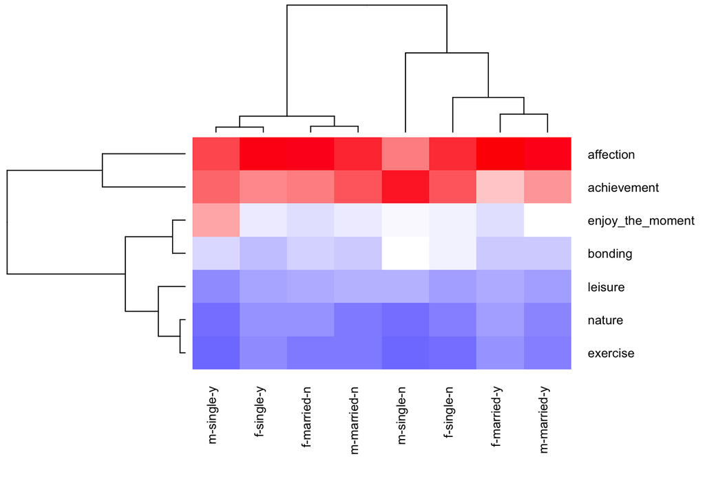

```r
heatmap_data <- bag_of_words %>%
  select(gender,marital,parenthood,predicted_category) %>%
  unite(category,c(gender,marital,parenthood), sep = '-') %>%
  count(category,predicted_category)

library(gplots)
heat_matrix <- matrix(heatmap_data$n,nrow = 7)
rownames(heat_matrix) <- heatmap_data$predicted_category[1:7]
colnames(heat_matrix) <- unique(heatmap_data$category)

# jpeg("../figs/bigrams_heatmap.jpeg") # used to save the plot
heatmap.2(heat_matrix,
          scale = "column", key=F,
          col = bluered(100),
          cexRow = 0.9, cexCol = 0.9, margins = c(8, 8),
          trace = "none", density.info = "none")
```

```r
# dev.off() # used to save the plot
```